# Sports Analytics Project

Jack Arbuckle, Ian Pezzella, and Reuben Dayal

2023-10-31

```r
# Load Packages:
library(tidyverse)
```

```r
library(ggplot2) # Load ggplot2
library(ggdark) # Load ggdark
library(ggimage) # Load ggimage
library(reshape) # Load reshape
library(ggridges) # Load ggridges
library(ggrepel) # Load ggrepellibrary(tidyverse) # Load tidyverse
library(GGally) # Load GGally
# Load Functions:
source("sports_analytics_functions.r")
#source("pbp_functions.r")
```

```r
load("team_logos.rda")
```

```r
library(cfbfastR)
# Load data
cfb_2023 <- load_cfb_pbp(seasons = 2023, weeks = c(1, 2, 3,4,5,6,7,8,9,10,11))
class(cfb_2023)
```

```
## [1] "cfbfastR_data" "tbl_df"        "tbl"           "data.table"
## [5] "data.frame"
```

```r
# Convert to data frame
cfb_2023 <- as.data.frame(cfb_2023)
```

```r
# Create summarized play type
s_play_type <- create_simplex_play_type(cfb_2023)
# Add summarized play type back to dataset
cfb_2023$playtype <- s_play_type
```

```r
# Create team level summary
team_summary <- create_team_summary(pbp = cfb_2023, # Set dataset
                                team_logos = team_logos) # Set logos to
```

The first few columns relate to team level information

- team_id - The ID code for each team
- school - The school name
- color - The school primary color
- alt_color - The school alternative color
- logos - Link to the school logo image
- games - The number of games played so far

The next few columns relate to the offensive performance of the school:

- pass_n - Number of passes thrown
- pass_yards - Total pass yards
- pass_epa - Total pass EPA (Expected points added)
- pass_wpa - Total pass WPA (Win probability added)
- rush_n - Number of rushes
- rush_yards - Total rush yards
- rush_epa - Total rush EPA (Expected points added)
- rush_wpa - Total Rush WPA (Win probability added)

We then have the offensive statistics at a per play level:

- pass_yards_per_play - Pass yards per play
- pass_epa_per_play - Pass EPA (Expected points added) per play
- pass_wpa_per_play - Pass WPA (Win probability added) per play
- rush_yards_per_play - Rush yards_per_play
- rush_epa_per_play - Rush EPA (Expected points added) per play
- rush_wpa_per_play - Rush WPA (Win probability added) per play

The next set of columns relate to the defensive performance of the school:

- pass_n_def - Number of passes defended
- pass_yards_def - Total pass yards against
- pass_epa_def - Total pass EPA against (Expected points added)
- pass_wpa_def - Total pass WPA against (Win probability added)
- rush_n_def - Number of rushes defended
- rush_yards_def - Total rush yards against
- rush_epa_def - Total rush EPA against (Expected points added)
- rush_wpa_def - Total rush WPA against (Win probability added)

Finally we have the defensive statistics at a per play level:

- pass_yards_per_play_def - Pass yards against per play
- pass_epa_per_play_def - Pass EPA against (Expected points added) per play
- pass_wpa_per_play_def - Pass WPA against (Win probability added) per play
- rush_yards_per_play_def - Rush yards against per play
- rush_epa_per_play_def - Rush EPA against (Expected points added) per play
- rush_wpa_per_play_def - Rush WPA against (Win probability added) per play

```r
CFP_schools <- team_summary %>%
  filter(school %in% c('Washington', 'Ohio State', 'Michigan','Florida State', 'Georgia'))

CFP_schools
```

```
##   team_id        school   color alt_color
## 1      52 Florida State #782F40   #ceb888
## 2      61       Georgia #CC0000   #000000
## 3     130      Michigan #00274c   #00274c
## 4     194    Ohio State #DE3121   #666666
## 5     264    Washington #2B2F64   #e8e3d3
##                                               logos games pass_n pass_yards
## 1  http://a.espncdn.com/i/teamlogos/ncaa/500/52.png    13    425       3240
## 2  http://a.espncdn.com/i/teamlogos/ncaa/500/61.png    13    429       3875
## 3 http://a.espncdn.com/i/teamlogos/ncaa/500/130.png    13    327       2688
## 4 http://a.espncdn.com/i/teamlogos/ncaa/500/194.png    12    380       3334
## 5 http://a.espncdn.com/i/teamlogos/ncaa/500/264.png    13    475       4296
##    pass_epa pass_wpa rush_n rush_yards  rush_epa   rush_wpa pass_yards_per_play
## 1  84.72365 1.995363    406       2265  9.708729 -0.1070578            7.623529
## 2 175.13983 4.089696    434       2381 66.254745  1.1887007            9.032634
```

[output cut: 33 more lines]

Power Five Opponents

```r
wash_opponents <- team_summary %>%
  filter(school %in% c('Michigan State', 'Colorado', 'Arizona', 'Oregon','Arizona State','Stanford', 'USC', 'Utah'))
wash_opponents
```

```
##   team_id         school   color alt_color
## 1      12        Arizona #002449   #00205b
## 2       9  Arizona State #942139   #f1f2f3
## 3      38       Colorado #d1c57e   #ffd200
## 4     127 Michigan State #18453B   #ffffff
## 5    2483         Oregon #044520   #fee123
## 6      24       Stanford #A80532   #ffffff
## 7      30            USC #ffc72c   #ae2531
## 8     254           Utah #890012   #7e8083
##                                                logos games pass_n pass_yards
## 1   http://a.espncdn.com/i/teamlogos/ncaa/500/12.png    12    430       3494
## 2    http://a.espncdn.com/i/teamlogos/ncaa/500/9.png    12    443       2567
## 3   http://a.espncdn.com/i/teamlogos/ncaa/500/38.png    12    515       3141
## 4  http://a.espncdn.com/i/teamlogos/ncaa/500/127.png    12    382       2233
## 5 http://a.espncdn.com/i/teamlogos/ncaa/500/2483.png    13    471       4460
```

[output cut: 57 more lines]

```r
osu_opponents <- team_summary %>%
  filter(school %in% c('Indiana', 'Notre Dame', 'Maryland', 'Purdue', 'Penn State', 'Wisconsin', 'Rutgers', 'Michigan State'))
osu_opponents
```

```
##   team_id         school   color alt_color
## 1      84        Indiana #7D110C   #eeedeb
## 2     120       Maryland #D5002B   #ffcd00
## 3     127 Michigan State #18453B   #ffffff
## 4      87     Notre Dame #00122b   #ae9142
## 5     213     Penn State #00265D   #002e5c
## 6    2509         Purdue #B89D29   #a4a9ad
## 7     164        Rutgers #d21034   #ffffff
## 8     275      Wisconsin #A00001   #f7f7f7
##                                                logos games pass_n pass_yards
## 1   http://a.espncdn.com/i/teamlogos/ncaa/500/84.png    12    375       2459
## 2  http://a.espncdn.com/i/teamlogos/ncaa/500/120.png    12    449       3238
## 3  http://a.espncdn.com/i/teamlogos/ncaa/500/127.png    12    382       2233
## 4   http://a.espncdn.com/i/teamlogos/ncaa/500/87.png    12    334       2914
## 5  http://a.espncdn.com/i/teamlogos/ncaa/500/213.png    11    350       1987
```

[output cut: 57 more lines]

```r
uga_opponents <- team_summary %>%
  filter(school %in% c('South Carolina', 'Auburn', 'Kentucky', 'Vanderbilt', 'Florida','Missouri', 'Ole Miss'))
uga_opponents
```

```
##   team_id         school   color alt_color
## 1       2         Auburn #03244d   #f1f2f3
## 2      57        Florida #0021A5   #0021a5
## 3      96       Kentucky #005DAA   #ffffff
## 4     142       Missouri #000000   #000000
## 5     145       Ole Miss #001148   #00205b
## 6    2579 South Carolina #670010   #000000
## 7     238     Vanderbilt #000000   #231f20
##                                                logos games pass_n pass_yards
## 1    http://a.espncdn.com/i/teamlogos/ncaa/500/2.png    12    295       1756
## 2   http://a.espncdn.com/i/teamlogos/ncaa/500/57.png    12    407       2911
## 3   http://a.espncdn.com/i/teamlogos/ncaa/500/96.png    12    351       2142
## 4  http://a.espncdn.com/i/teamlogos/ncaa/500/142.png    12    365       3070
## 5  http://a.espncdn.com/i/teamlogos/ncaa/500/145.png    11    349       2912
## 6 http://a.espncdn.com/i/teamlogos/ncaa/500/2579.png    12    444       3135
```

[output cut: 49 more lines]

```r
fsu_opponents <- team_summary %>%
  filter(school %in% c('Louisiana', 'Boston College', 'Clemson','Virginia Tech', 'Syracuse', 'Duke', 'Wake Forest', 'Pittsburgh','Miami'))
fsu_opponents
```

```
##   team_id         school   color alt_color
## 1     103 Boston College #88001a   #a39161
## 2     228        Clemson #F66733   #522d80
## 3     150           Duke #001A57   #f1f2f3
## 4     309      Louisiana #ce2842      <NA>
## 5    2390          Miami #004325   #f0f0f0
## 6     221     Pittsburgh #003263   #231f20
## 7     183       Syracuse #F37321   #0d1d37
## 8     259  Virginia Tech #74232D   #c2c1ba
## 9     154    Wake Forest #9E7E38   #000000
##                                                logos games pass_n pass_yards
## 1  http://a.espncdn.com/i/teamlogos/ncaa/500/103.png    12    342       2095
## 2  http://a.espncdn.com/i/teamlogos/ncaa/500/228.png    12    437       2718
## 3  http://a.espncdn.com/i/teamlogos/ncaa/500/150.png    12    325       2069
## 4  http://a.espncdn.com/i/teamlogos/ncaa/500/309.png    12    342       2543
```

[output cut: 65 more lines]

```r
mich_opponents <- team_summary %>%
  filter(school %in% c('Rutgers', 'Nebraska', 'Minnesota','Indiana', 'Michigan State', 'Purdue', 'Penn State'))
mich_opponents
```

```
##   team_id         school   color alt_color
## 1      84        Indiana #7D110C   #eeedeb
## 2     127 Michigan State #18453B   #ffffff
## 3     135      Minnesota #981a31   #981a31
## 4     158       Nebraska #F20017   #f5f1e7
## 5     213     Penn State #00265D   #002e5c
## 6    2509         Purdue #B89D29   #a4a9ad
## 7     164        Rutgers #d21034   #ffffff
##                                                logos games pass_n pass_yards
## 1   http://a.espncdn.com/i/teamlogos/ncaa/500/84.png    12    375       2459
## 2  http://a.espncdn.com/i/teamlogos/ncaa/500/127.png    12    382       2233
## 3  http://a.espncdn.com/i/teamlogos/ncaa/500/135.png    12    307       1744
## 4  http://a.espncdn.com/i/teamlogos/ncaa/500/158.png    12    264       1459
## 5  http://a.espncdn.com/i/teamlogos/ncaa/500/213.png    11    350       1987
## 6 http://a.espncdn.com/i/teamlogos/ncaa/500/2509.png    12    399       2347
```

[output cut: 49 more lines]

```r
average_fsu<- c((mean(fsu_opponents$pass_epa_per_play)),(mean(fsu_opponents$pass_epa_per_play_def)), (mean(fsu_opponents$rush_epa_per_play_def)), (mean(fsu_opponents$rush_epa_per_play)))

average_mich<- c((mean(mich_opponents$pass_epa_per_play)),(mean(mich_opponents$pass_epa_per_play_def)), (mean(mich_opponents$rush_epa_per_play_def)),(mean(mich_opponents$rush_epa_per_play)))

average_osu<- c((mean(osu_opponents$pass_epa_per_play)),(mean(osu_opponents$pass_epa_per_play_def)), (mean(osu_opponents$rush_epa_per_play_def)), (mean(osu_opponents$rush_epa_per_play)))

average_uga<- c((mean(uga_opponents$pass_epa_per_play)),(mean(uga_opponents$pass_epa_per_play_def)), (mean(uga_opponents$rush_epa_per_play_def)), (mean(uga_opponents$rush_epa_per_play)))

average_wash<- c((mean(wash_opponents$pass_epa_per_play)),(mean(wash_opponents$pass_epa_per_play_def)), (mean(wash_opponents$rush_epa_per_play_def)), (mean(wash_opponents$rush_epa_per_play)))


all_opponents_avg <- data.frame(
  school = c("Florida State", "Michigan", "Washington", "Ohio State", "Georgia"),
  opp_pass_epa_per_play = c(average_fsu[1], average_mich[1], average_wash[1], average_osu[1], average_uga[1]),
  opp_pass_epa_per_play_def = c(average_fsu[2], average_mich[2], average_wash[2], average_osu[2], average_uga[2]),
  opp_rush_epa_per_play_def = c(average_fsu[3], average_mich[3], average_wash[3], average_osu[3], average_uga[3]),
  opp_rush_epa_per_play = c(average_fsu[4], average_mich[4], average_wash[4], average_osu[4], average_uga[4]))

all_opponents_avg <- merge(all_opponents_avg, CFP_schools, by = "school")




# Display the resulting data frame
print(all_opponents_avg)
```

```
##          school opp_pass_epa_per_play opp_pass_epa_per_play_def
## 1 Florida State            0.11521890                0.10543911
## 2       Georgia            0.16949748                0.14882551
## 3      Michigan            0.02567945                0.08567367
## 4    Ohio State            0.09802189                0.04484506
## 5    Washington            0.15195011                0.13910828
##   opp_rush_epa_per_play_def opp_rush_epa_per_play team_id   color alt_color
## 1               0.029170875            0.07126552      52 #782F40   #ceb888
## 2               0.060628823            0.05574465      61 #CC0000   #000000
## 3              -0.004851123            0.03200915     130 #00274c   #00274c
## 4               0.003800344            0.04992032     194 #DE3121   #666666
## 5               0.072672481            0.07495287     264 #2B2F64   #e8e3d3
##                                               logos games pass_n pass_yards
## 1  http://a.espncdn.com/i/teamlogos/ncaa/500/52.png    13    425       3240
## 2  http://a.espncdn.com/i/teamlogos/ncaa/500/61.png    13    429       3875
```

[output cut: 39 more lines]

```r
# Create plot
OPP_Def_EPA_Per_Play_plot <- ggplot(data = all_opponents_avg, # Set dataset
                 aes(x = opp_pass_epa_per_play_def, # Set x-axis variable
                     y = opp_rush_epa_per_play_def)) + # Set y-axis variable
  geom_point() + # Set geom point to create scatter plot
  geom_image(image = CFP_schools$logos, asp = 16/9) + # Add logos
   labs(x = "Opponents Pass EPA DEF Per Play", # Add labels
       y = "Opponents Rush EPA Def Per Play",
       title = "Opponents: Rush v Pass EPA Def Per Play",
       subtitle = "Higher EPA indicates team has played weaker defenses")

# Turn off dark mode
invert_geom_defaults()


ggsave(OPP_Def_EPA_Per_Play_plot, file = 'OPP_Def_EPA_Per_Play_plot.jpg', width = 10, height = 10, dpi = 600)
```

```r
# Create plot
OPP_Off_EPA_Per_Play_plot <- ggplot(data = all_opponents_avg, # Set dataset
                 aes(x = opp_pass_epa_per_play, # Set x-axis variable
                     y = opp_rush_epa_per_play)) + # Set y-axis variable
  geom_point() + # Set geom point to create scatter plot
  geom_image(image = CFP_schools$logos, asp = 16/9) + # Add logos
   labs(x = "Opponent Pass EPA Per Play", # Add labels
       y = "Opponent Rush EPA Def Per Play",
       title = "Opponents: Rush v Pass EPA Per Play",
       subtitle = "Higher EPA indicates team has played stronger offenses")

# Turn off dark mode
invert_geom_defaults()


ggsave(OPP_Off_EPA_Per_Play_plot, file = 'OPP_Off_EPA_Per_Play_plot.jpg', width = 10, height = 10, dpi = 600)
```

```r
# Create plot
Off_EPA_Per_Play_plot <- ggplot(data = CFP_schools, # Set dataset
                 aes(x = rush_epa_per_play, # Set x-axis variable
                     y = pass_epa_per_play)) + # Set y-axis variable
  geom_point() + # Set geom point to create scatter plot
  geom_image(image = CFP_schools$logos, asp = 16/9) + # Add logos
  dark_theme_bw() + # Set dark theme
   labs(x = "Rush EPA Per Play", # Add labels
       y = "Pass EPA Per Play",
       title = "Rush v Pass EPA Per Play",
       subtitle = "Higher EPA indicates stronger offense")
```

```
## Inverted geom defaults of fill and color/colour.
## To change them back, use invert_geom_defaults().
```

```r
# Turn off dark mode
invert_geom_defaults()

ggsave(Off_EPA_Per_Play_plot, file = 'Off_EPA_Per_Play_plot.jpg', width = 10, height = 10, dpi = 600)
```

```r
# Create plot
Def_EPA_Per_Play_plot <- ggplot(data = CFP_schools, # Set dataset
                 aes(x = rush_epa_per_play_def, # Set x-axis variable
                     y = pass_epa_per_play_def)) + # Set y-axis variable
  geom_point() + # Set geom point to create scatter plot
  geom_image(image = CFP_schools$logos, asp = 16/9) + # Add logos
  dark_theme_bw() + # Set dark theme
   labs(x = "Rush EPA DEF Per Play", # Add labels
       y = "Pass EPA DEF Per Play",
       title = "Rush v Pass EPA DEF Per Play",
       subtitle = "Lower EPA indicates stronger defense")
```

```
## Inverted geom defaults of fill and color/colour.
## To change them back, use invert_geom_defaults().
```

```r
# Turn off dark mode
invert_geom_defaults()


ggsave(Def_EPA_Per_Play_plot, file = 'Def_EPA_Per_Play_plot.jpg', width = 10, height = 10, dpi = 600)
```

```r
number_of_passvsrush_plays_plot <- ggplot(data = CFP_schools, # Set dataset
                 aes(x = rush_n, # Set x-axis variable
                     y = pass_n)) + # Set y-axis variable
  geom_point() + # Set geom point to create scatter plot
  geom_image(image = CFP_schools$logos, asp = 16/9) + # Add logos
  dark_theme_bw() + # Set dark theme
   labs(x = "Number of Rushes", # Add labels
       y = "Number of Passes",
       title = "Rush v Passing Plays",
       subtitle = "CFB 2023")
```

```
## Inverted geom defaults of fill and color/colour.
## To change them back, use invert_geom_defaults().
```

```r
# Turn off dark mode
invert_geom_defaults()


ggsave(number_of_passvsrush_plays_plot, file = 'number_of_passvsrush_plays_plot.jpg', width = 10, height = 10, dpi = 600)
```

Create weighted EPA for all teams based on Schedule

```r
weighted_off_def <- all_opponents_avg %>%
  mutate(weighted_passing_off = 10*((1/(0.5+opp_pass_epa_per_play_def))*(pass_epa_per_play+0.5)))%>%
mutate(weighted_rushing_off = 10*((1/(0.5+opp_rush_epa_per_play_def)) * (rush_epa_per_play+0.5)))%>%
  mutate(weighted_passing_def = 10*((1/(0.5+opp_pass_epa_per_play)) * (pass_epa_per_play_def+0.5)))%>%
  mutate(weighted_rushing_def = 10*((1/(0.5+opp_rush_epa_per_play)) * (rush_epa_per_play_def+0.5)))

weighted_off_def
```

```
##          school opp_pass_epa_per_play opp_pass_epa_per_play_def
## 1 Florida State            0.11521890                0.10543911
## 2       Georgia            0.16949748                0.14882551
## 3      Michigan            0.02567945                0.08567367
## 4    Ohio State            0.09802189                0.04484506
## 5    Washington            0.15195011                0.13910828
##   opp_rush_epa_per_play_def opp_rush_epa_per_play team_id   color alt_color
## 1               0.029170875            0.07126552      52 #782F40   #ceb888
## 2               0.060628823            0.05574465      61 #CC0000   #000000
## 3              -0.004851123            0.03200915     130 #00274c   #00274c
## 4               0.003800344            0.04992032     194 #DE3121   #666666
## 5               0.072672481            0.07495287     264 #2B2F64   #e8e3d3
##                                               logos games pass_n pass_yards
## 1  http://a.espncdn.com/i/teamlogos/ncaa/500/52.png    13    425       3240
## 2  http://a.espncdn.com/i/teamlogos/ncaa/500/61.png    13    429       3875
```

[output cut: 45 more lines]

```r
weighted_off_plot<- ggplot(data = weighted_off_def, # Set dataset
                 aes(x = weighted_off_def$weighted_rushing_off, # Set x-axis variable
                     y = weighted_off_def$weighted_passing_off)) + # Set y-axis variable
  geom_point() + # Set geom point to create scatter plot
  geom_image(image = CFP_schools$logos, asp = 16/9) + # Add logos
  dark_theme_bw() + # Set dark theme
   labs(x = "Weighted Rushing Offense", # Add labels
       y = "Weighted Passing Offense",
       title = "Weighted Offense",
       subtitle = "CFB 2023")
```

```
## Inverted geom defaults of fill and color/colour.
## To change them back, use invert_geom_defaults().
```

```r
# Turn off dark mode
invert_geom_defaults()

ggsave(weighted_off_plot, file = 'Weighted_Off_Plot.jpg', width = 10, height = 10, dpi = 600)
weighted_def_plot <- ggplot(data = weighted_off_def, # Set dataset
                 aes(x = weighted_off_def$weighted_rushing_def, # Set x-axis variable
                     y = weighted_off_def$weighted_passing_def)) + # Set y-axis variable
  geom_point() + # Set geom point to create scatter plot
  geom_image(image = CFP_schools$logos, asp = 16/9) + # Add logos
  dark_theme_bw() + # Set dark theme
   labs(x = "Weighted Rushing Defense", # Add labels
       y = "Weighted Passing Defense",
       title = "Weighted Defense",
       subtitle = "CFB 2023")
```

```
## Inverted geom defaults of fill and color/colour.
## To change them back, use invert_geom_defaults().
```

```r
# Turn off dark mode
invert_geom_defaults()


ggsave(weighted_def_plot, file = 'Weighted_Def_Plot.jpg', width = 10, height = 10, dpi = 600)
weighted_pass_defvsoff_plot <- ggplot(data = weighted_off_def, # Set dataset
                 aes(x = weighted_off_def$weighted_passing_def, # Set x-axis variable
                     y = weighted_off_def$weighted_passing_off)) + # Set y-axis variable
  geom_point() + # Set geom point to create scatter plot
  geom_image(image = CFP_schools$logos, asp = 16/9) + # Add logos
  dark_theme_bw() + # Set dark theme
   labs(x = "Weighted Passing Defense", # Add labels
       y = "Weighted Passing Offense",
       title = "Passing Def vs Passing Off",
       subtitle = "CFB 2023")
```

```
## Inverted geom defaults of fill and color/colour.
## To change them back, use invert_geom_defaults().
```

```r
# Turn off dark mode
invert_geom_defaults()


ggsave(weighted_pass_defvsoff_plot, file = 'weighted_pass_defvsoff.jpg', width = 10, height = 10, dpi = 600)
weighted_rush_defvsoff_plot <- ggplot(data = weighted_off_def, # Set dataset
                 aes(x = weighted_off_def$weighted_rushing_def, # Set x-axis variable
                     y = weighted_off_def$weighted_rushing_off)) + # Set y-axis variable
  geom_point() + # Set geom point to create scatter plot
  geom_image(image = CFP_schools$logos, asp = 16/9) + # Add logos
  dark_theme_bw() + # Set dark theme
   labs(x = "Weighted Rushing Defense", # Add labels
       y = "Weighted Rushing Offense",
       title = "Rushing Def vs Rushing Off",
       subtitle = "CFB 2023")
```

```
## Inverted geom defaults of fill and color/colour.
## To change them back, use invert_geom_defaults().
```

```r
# Turn off dark mode
invert_geom_defaults()


ggsave(weighted_rush_defvsoff_plot, file = 'weighted_rush_defvsoff.jpg', width = 10, height = 10, dpi = 600)
washvsosu <- weighted_off_def %>%
  filter(school %in% c("Washington", "Ohio State"))%>%
mutate(Wash_Passing_Off = 10*(weighted_passing_off[2] * weighted_passing_def[1]))%>%
mutate(Wash_Rushing_Off = 10*(weighted_rushing_off[2] * weighted_rushing_def[1]))%>%
mutate(OSU_Passing_Off = 10*(weighted_passing_off[1] * weighted_passing_def[2]))%>%
mutate(OSU_Rushing_Off = 10*(weighted_rushing_off[1] * weighted_rushing_def[2]))
```

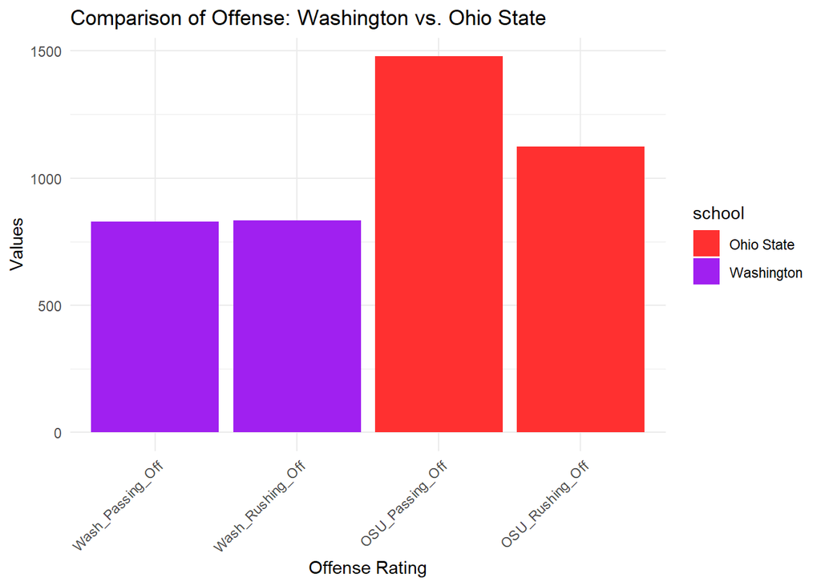

```r
selected_columns <- c("Wash_Passing_Off", "Wash_Rushing_Off", "OSU_Passing_Off", "OSU_Rushing_Off")

# Melt the dataframe to long format for easier plotting
melted_data_osu <- melt(washvsosu, id.vars = "school", measure.vars = selected_columns)

selected_rows_osu <- melted_data_osu %>%
  slice(c(2, 4, 5, 7))

# Create a grouped bar plot
washvsosu_plot<- ggplot(selected_rows_osu, aes(x = variable, y = value,fill = school)) +
  geom_bar(stat = "identity", position = "dodge") +
  labs(title = "Comparison of Offense: Washington vs. Ohio State",
       x = "Offense Rating", y = "Values") +
  scale_fill_manual(values = c("firebrick1", "purple")) +
  theme_minimal() +
  theme(axis.text.x = element_text(angle = 45, hjust = 1))

washvsosu_plot
```

```r
ggsave(washvsosu_plot, file = 'washvsosu_plot.jpg', width = 10, height = 10, dpi = 600)
```

```r
washvsmich <- weighted_off_def %>%
  filter(school %in% c("Washington", "Michigan"))%>%
mutate(Wash_Passing_Off = 10*(weighted_passing_off[2] * weighted_passing_def[1]))%>%
mutate(Wash_Rushing_Off = 10*(weighted_rushing_off[2] * weighted_rushing_def[1]))%>%
mutate(Mich_Passing_Off = 10*(weighted_passing_off[1] * weighted_passing_def[2]))%>%
mutate(Mich_Rushing_Off = 10*(weighted_rushing_off[1] * weighted_rushing_def[2]))

selected_columns <- c("Wash_Passing_Off", "Wash_Rushing_Off", "Mich_Passing_Off", "Mich_Rushing_Off")

# Melt the dataframe to long format for easier plotting
melted_data_mich <- melt(washvsmich, id.vars = "school", measure.vars = selected_columns)

selected_rows_mich <- melted_data_mich %>%
  slice(c(2, 4, 5, 7))

# Create a grouped bar plot
washvsmich_plot <- ggplot(selected_rows_mich, aes(x = variable, y = value, fill = school)) +
  geom_bar(stat = "identity", position = "dodge") +
  dark_theme_bw() + # Set dark theme
  labs(title = "Comparison of Offense: Washington vs. Michigan",
       x = "Offense Rating", y = "Values") +
  scale_fill_manual(values = c("navy", "purple")) +
  theme_minimal() +
  theme(axis.text.x = element_text(angle = 45, hjust = 1))
```

```
## Inverted geom defaults of fill and color/colour.
## To change them back, use invert_geom_defaults().
```

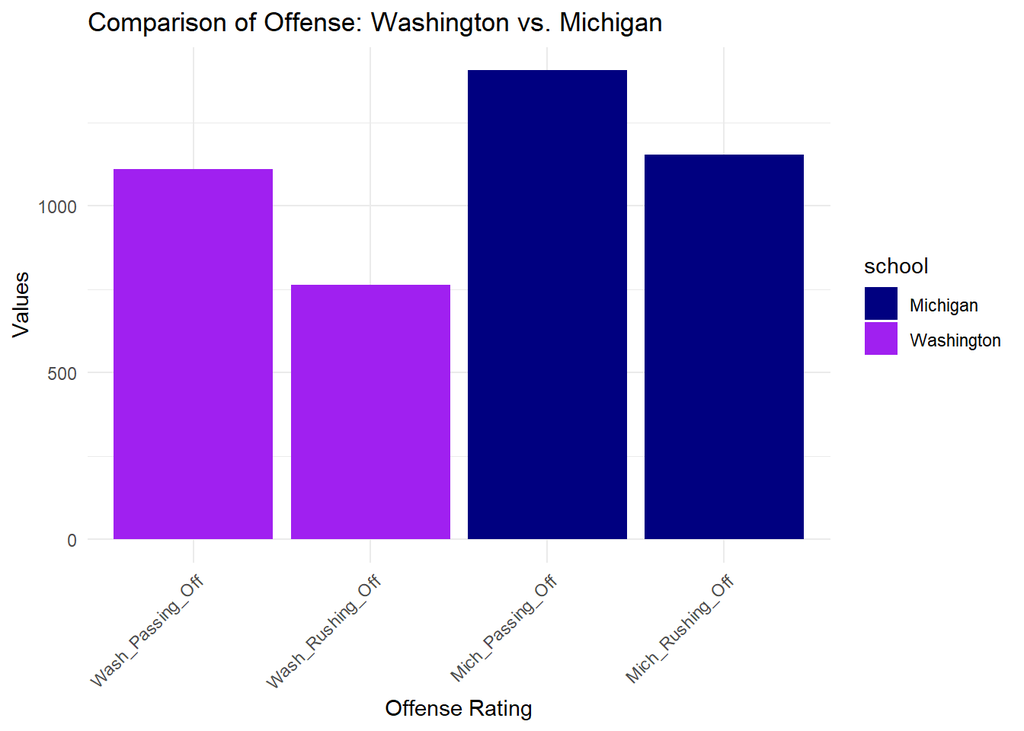

```r
washvsmich_plot
```

```r
ggsave(washvsmich_plot, file = 'washvsmich_plot.jpg', width = 10, height = 10, dpi = 600)
```

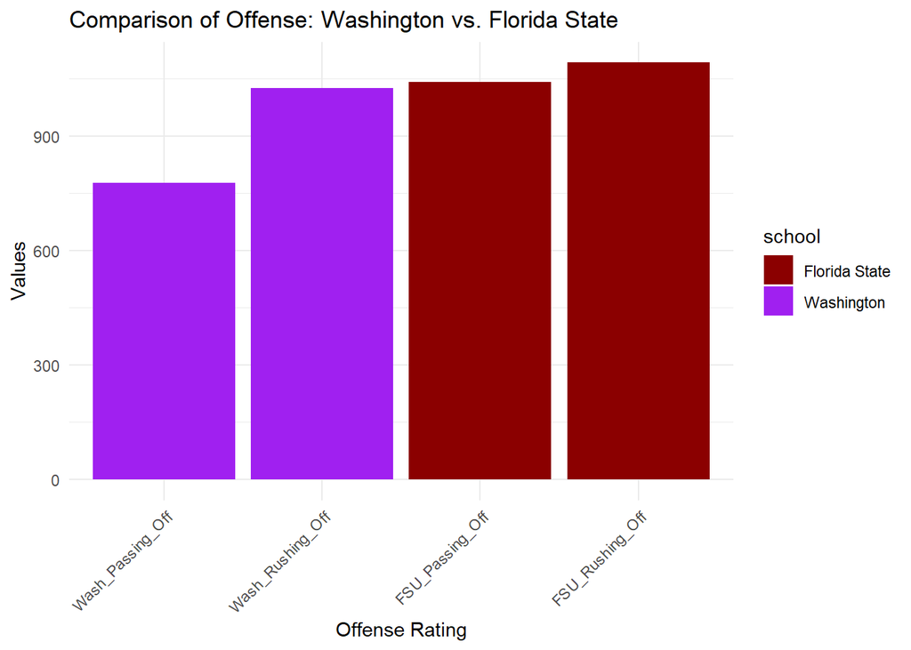

```r
washvsfsu <- weighted_off_def %>%
  filter(school %in% c("Washington", "Florida State"))%>%
mutate(Wash_Passing_Off = 10*(weighted_passing_off[2] * weighted_passing_def[1]))%>%
mutate(Wash_Rushing_Off = 10*(weighted_rushing_off[2] *weighted_rushing_def[1]))%>%
mutate(FSU_Passing_Off = 10*(weighted_passing_off[1] * weighted_passing_def[2]))%>%
mutate(FSU_Rushing_Off = 10*(weighted_rushing_off[1] * weighted_rushing_def[2]))

selected_columns <- c("Wash_Passing_Off", "Wash_Rushing_Off", "FSU_Passing_Off", "FSU_Rushing_Off")

# Melt the dataframe to long format for easier plotting
melted_data_fsu <- melt(washvsfsu, id.vars = "school", measure.vars = selected_columns)

selected_rows_fsu <- melted_data_fsu %>%
  slice(c(2, 4, 5, 7))

# Create a grouped bar plot
washvsfsu_plot<- ggplot(selected_rows_fsu, aes(x = variable, y = value, fill = school)) +
  geom_bar(stat = "identity", position = "dodge") +
  labs(title = "Comparison of Offense: Washington vs. Florida State",
       x = "Offense Rating", y = "Values") +
  scale_fill_manual(values = c("darkred", "purple")) +
  theme_minimal() +
  theme(axis.text.x = element_text(angle = 45, hjust = 1))

washvsfsu_plot
```

```r
ggsave(washvsfsu_plot, file = 'washvsfsu_plot.jpg', width = 10, height = 10, dpi = 600)
```

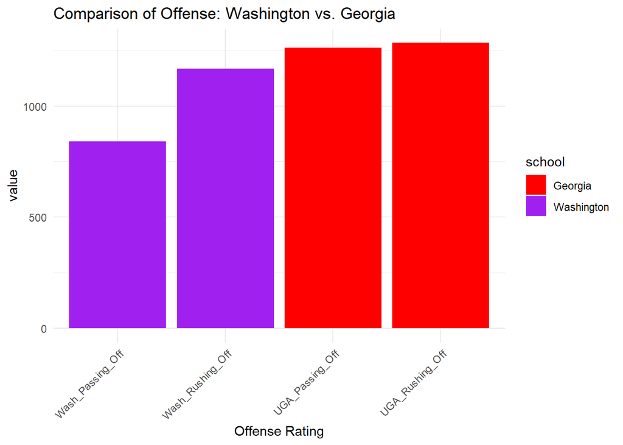

```r
washvsuga <- weighted_off_def %>%
  filter(school %in% c("Washington", "Georgia"))%>%
mutate(Wash_Passing_Off = 10*(weighted_passing_off[2] * weighted_passing_def[1]))%>%
mutate(Wash_Rushing_Off = 10*(weighted_rushing_off[2] * weighted_rushing_def[1]))%>%
mutate(UGA_Passing_Off = 10*(weighted_passing_off[1] * weighted_passing_def[2]))%>%
mutate(UGA_Rushing_Off = 10*(weighted_rushing_off[1] * weighted_rushing_def[2]))

selected_columns <- c("Wash_Passing_Off", "Wash_Rushing_Off", "UGA_Passing_Off", "UGA_Rushing_Off")

# Melt the dataframe to long format for easier plotting
melted_data_uga <- melt(washvsuga, id.vars = "school", measure.vars = selected_columns)

selected_rows_uga <- melted_data_uga %>%
  slice(c(2, 4, 5, 7))

# Create a grouped bar plot
washvsuga_plot <- ggplot(selected_rows_uga, aes(x = variable, y = value, fill = school)) +
  geom_bar(stat = "identity", position = "dodge") +
  labs(title = "Comparison of Offense: Washington vs. Georgia",
       x = "Offense Rating") +
  scale_fill_manual(values = c("red", "purple")) +
  theme_minimal() +
  theme(axis.text.x = element_text(angle = 45, hjust = 1))

washvsuga_plot
```

```r
ggsave(washvsuga_plot, file = 'washvsuga_plot.jpg', width = 10, height = 10, dpi = 600)
```